# Iterations with apply and do

## `lapply`: getting quantiles

- `qlist` is a list of 82 data frames, one for each building

```r
> bld_names[1]
[1] "100_Nevada_Street"
> qlist[[1]]
# A tibble: 9 × 4
  building               q     p qtype
  <chr>              <dbl> <dbl> <chr>
1 100_Nevada_Street 0.0972   0.1 Perc10%
2 100_Nevada_Street 0.120    0.2 Perc20%
3 100_Nevada_Street 0.183    0.3 Perc30%
4 100_Nevada_Street 0.461    0.4 Perc40%
5 100_Nevada_Street 0.710    0.5 Perc50%
6 100_Nevada_Street 0.795    0.6 Perc60%
7 100_Nevada_Street 0.915    0.7 Perc70%
8 100_Nevada_Street 1.11     0.8 Perc80%
9 100_Nevada_Street 1.24     0.9 Perc90%
```

## `lapply`: getting quantiles

```r
> bld_names[82]
[1] "Wilson_House"
> qlist[[82]]
# A tibble: 9 × 4
  building         q     p qtype
  <chr>        <dbl> <dbl> <chr>
1 Wilson_House 0.848   0.1 Perc10%
2 Wilson_House 0.892   0.2 Perc20%
3 Wilson_House 0.935   0.3 Perc30%
4 Wilson_House 1.01    0.4 Perc40%
5 Wilson_House 1.04    0.5 Perc50%
6 Wilson_House 1.17    0.6 Perc60%
7 Wilson_House 1.23    0.7 Perc70%
8 Wilson_House 1.26    0.8 Perc80%
9 Wilson_House 1.30    0.9 Perc90%
```

## `lapply`: getting quantiles

- The `dplyr` command `bind_rows()` coerces a list of similar data frames into one data frame
  - this is why I made `qfun` return a data frame!

```r
> 82*9  # number of rows in qdf
[1] 738
> qdf <- qlist %>% bind_rows() %>% print()
# A tibble: 738 × 4
   building               q     p qtype
   <chr>              <dbl> <dbl> <chr>
 1 100_Nevada_Street 0.0972   0.1 Perc10%
 2 100_Nevada_Street 0.120    0.2 Perc20%
 3 100_Nevada_Street 0.183    0.3 Perc30%
 4 100_Nevada_Street 0.461    0.4 Perc40%
 5 100_Nevada_Street 0.710    0.5 Perc50%
 6 100_Nevada_Street 0.795    0.6 Perc60%
 7 100_Nevada_Street 0.915    0.7 Perc70%
 8 100_Nevada_Street 1.11     0.8 Perc80%
 9 100_Nevada_Street 1.24     0.9 Perc90%
10 104_Maple_St.     1.04     0.1 Perc10%
# … with 728 more rows
```

## `lapply`: getting quantiles

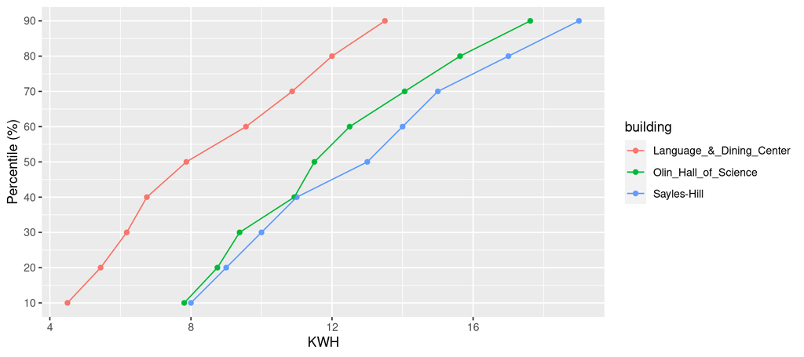

```r
> qdf %>% filter(building %in% c("Sayles-Hill" ,"Language_&_Dining_Center", "Olin_Hall_of_Science"))  %>%
+   ggplot(aes(x=q, y=p*100, color=building)) +
+   geom_point() + geom_line(aes(group=building)) + labs(y="Percentile (%)",x="KWH") +
+   scale_y_continuous(breaks=seq(10,90,by=10))
```

## `do` in `dplyr`

- the previous `lapply` can’t quickly be generalized to other groupings
  - e.g. get quantiles by month? or day of the week?
  - `qfun` needed to `filter` by `building`
- the `do` command in `dplyr` lets you apply a function to the groups of a data frame:
- Idea:
  - write a function `FUN` for a (hypothetical) subsetted version of the data
  - `FUN` must return a data frame or objects in a list
  - `group_by` to define a subsetted data frame
  - `do(FUN)` runs the `FUN` on the data frames defined by `group_by`

## `do` in `dplyr`: getting quantiles

- Redo quantile example with modified function (no need to filter groups):

```r
> qfun2 <- function(data) {
+   # get quantiles .1 thru .9
+   q <- quantile(data$energyKWH, probs = seq(.1, .9, by = .1), na.rm=TRUE)
+   # make data frame
+   data_frame(q,
+              p = seq(.1,.9,by=.1),
+              qtype = str_c("Perc", 100*seq(.1,.9,by=.1),"%"))
+ }
```

## `do` in `dplyr`: getting quantiles

- group by building
- then `do(qfun2(data = .))` where `.` will be filled by subsets of the data defined by the groups

```r
> qdf2 <- energy_narrow %>%
+   group_by(building) %>%
+   do(qfun2(data = .))
> qdf2  # done! same as qdf data!
# A tibble: 738 × 4
# Groups:   building [82]
   building               q     p qtype
   <chr>              <dbl> <dbl> <chr>
 1 100_Nevada_Street 0.0972   0.1 Perc10%
 2 100_Nevada_Street 0.120    0.2 Perc20%
 3 100_Nevada_Street 0.183    0.3 Perc30%
 4 100_Nevada_Street 0.461    0.4 Perc40%
 5 100_Nevada_Street 0.710    0.5 Perc50%
 6 100_Nevada_Street 0.795    0.6 Perc60%
 7 100_Nevada_Street 0.915    0.7 Perc70%
 8 100_Nevada_Street 1.11     0.8 Perc80%
 9 100_Nevada_Street 1.24     0.9 Perc90%
10 104_Maple_St.     1.04     0.1 Perc10%
# … with 728 more rows
```

## `do` in `dplyr`: getting quantiles

- group by building *and* day of the week

```r
> qdf3 <- energy_narrow %>%
+   group_by(building, dayWeek) %>%
+   do(qfun2(data = .))
> qdf3
# A tibble: 5,166 x 5
# Groups:   building, dayWeek [574]
   building          dayWeek      q     p qtype
   <chr>             <fct>    <dbl> <dbl> <chr>
 1 100_Nevada_Street Mon     0.0972   0.1 Perc10%
 2 100_Nevada_Street Mon     0.120    0.2 Perc20%
 3 100_Nevada_Street Mon     0.183    0.3 Perc30%
 4 100_Nevada_Street Mon     0.680    0.4 Perc40%
 5 100_Nevada_Street Mon     0.710    0.5 Perc50%
 6 100_Nevada_Street Mon     0.795    0.6 Perc60%
 7 100_Nevada_Street Mon     0.915    0.7 Perc70%
 8 100_Nevada_Street Mon     1.11     0.8 Perc80%
 9 100_Nevada_Street Mon     1.24     0.9 Perc90%
10 100_Nevada_Street Tues    0.0972   0.1 Perc10%
# ... with 5,156 more rows
```

## `do` in `dplyr`: getting quantiles

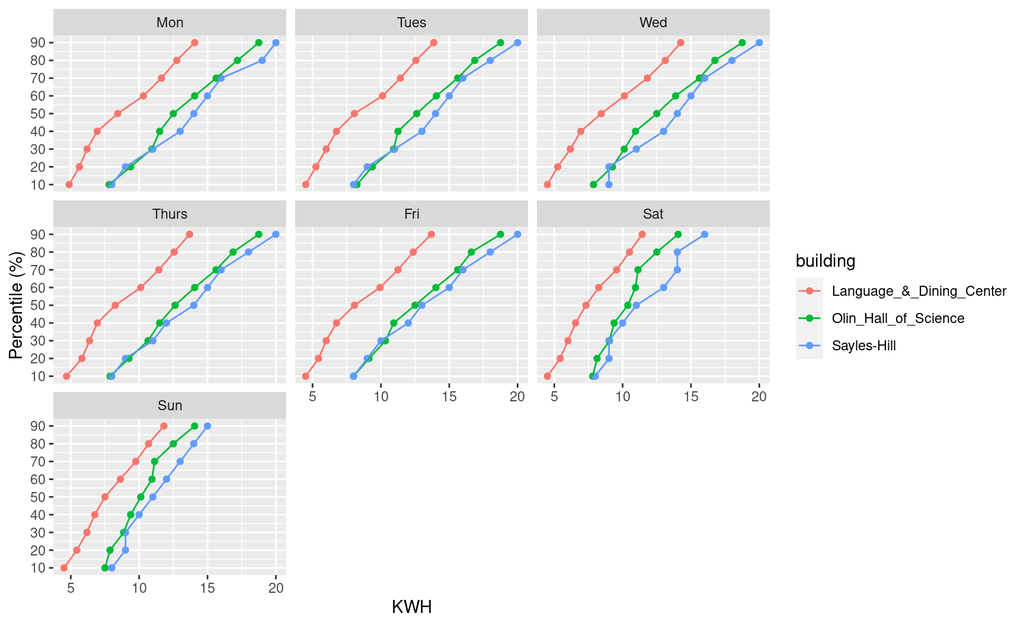

## Summary

- `apply()` - use if you have a matrix
- `lapply()` - much more general application (ie, can use for `library()`)
- `dplyr::do()` - applying custom functions to the framework of `dplyr` `group_by`